# Salary

Yang Su Hyeong

2020 6 12

```r
library(ggplot2)
library(scales)
library(gridExtra)
library(grid)
library(corrplot)
library(RColorBrewer)

# data manipulation
library(dplyr); library(readr); library(data.table)
library(forcats) ## factor manipulation
library(stringr); library(tidyr); library(tibble)
library(lazyeval); library(broom); library(purrr)
library(reshape2); library(rlang)

#library(ggrepel); library(ggforce); library(ggridges)
library(countrycode); library(geofacet); library(highcharter)
library(plotly)

## code start :
path <- "D:/project/ML_DS/"

multiple <- read_csv("D:/project/ML_DS/multipleChoiceResponses.csv", na=character()) %>%
  slice(2:n()) %>%
  rename("duration" = `Time from Start to Finish (seconds)`)
```

## 1. Duration outlier 제거하기 :

```r
##Preprocessing
## 1. Country - 5개 대륙으로 나눔. done
## 2. Salary - 결측치 제거하지 않음. 극단적인 이상치만 제거.  done
## 3. Student - 다 넣고 진행함. (salary no selection이 많음.)
## 4. 변수 내 grouping 필요 - ML 총 5개로 재분류 필요.
## DS, DA, Others, Software Engineer, Student
## 복수 응답지 남기고 나머지 제거. done
## Student : 살리기.
## Confidence NA : 제거할 것. done
## Duration Time : 제거에만 활용. done

vars <- c(gender = "Q1",
          country = "Q3",
          degree = "Q4",
          Role = "Q6",
          Age = "Q2",
          undergraduate_major = "Q5",
          industry = "Q7",
          Experience = "Q8",
          value = "Q9",
          confidence = "Q26")

multiple <- multiple %>% rename(!!vars)

multiple$duration <- as.numeric(multiple$duration)

## 필요없는 변수 제거 - 복스응답, 분석에 관계 없는 변수 제거하기
multiple <- multiple %>%
  select(-contains("OTHER_TEXT")) %>%
  select(-contains("Q33")) %>%
  select(-contains("Q39")) %>%
  select(-c("Q17", "Q18","Q20", "Q22", "Q32", "Q37", "Q12_MULTIPLE_CHOICE"))

## Duration : 너무 적은 시간 or 너무 오래 걸린 사람들 제거.
summary(multiple$duration/60.)
```

```
##      Min.   1st Qu.    Median      Mean   3rd Qu.      Max.
##     0.267     9.500    17.017   201.879    30.700 14760.650
```

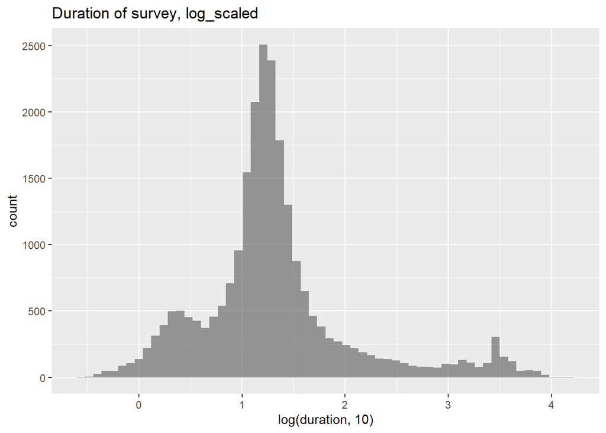

```r
multiple %>%
  mutate(duration = duration/60.) %>%
  select(c(duration)) %>%
  ggplot(aes(log(duration,10))) + geom_histogram(bins = 60, alpha=0.6, position = "identity") +
  ggtitle("Duration of survey, log_scaled")
```

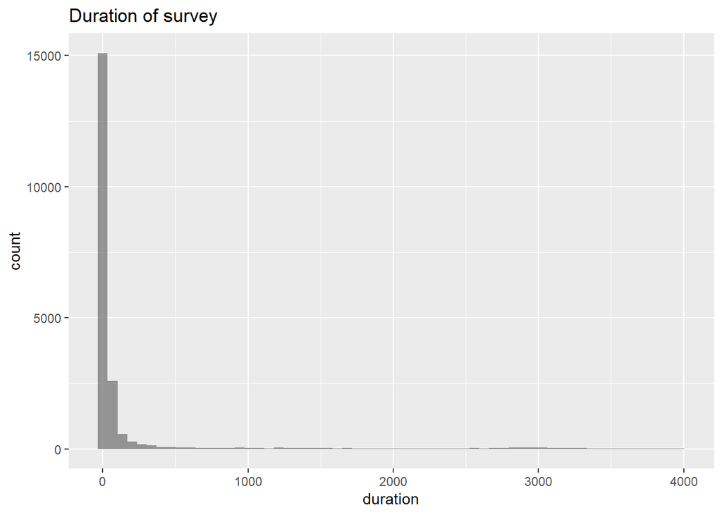

```r
## 4000 분(10^3 * 4) 이상 제거, 3분 이하 체거??

multiple %>%
  mutate(duration = duration/60.) %>%
  filter(duration < 4000) %>%
  filter(duration > 4) %>%
  select(c(duration)) %>%
  ggplot(aes(duration)) + geom_histogram(bins = 60, alpha=0.6, position = "identity") +
  ggtitle("Duration of survey")
```

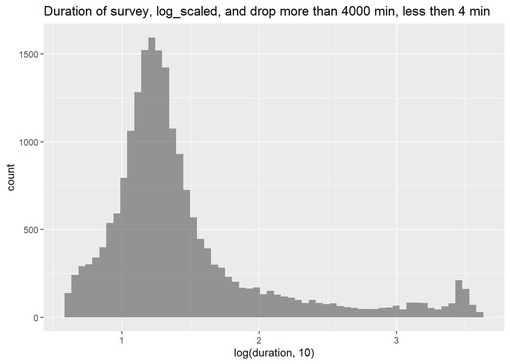

```r
multiple %>%
  mutate(duration = duration/60.) %>%
  filter(duration < 4000) %>%
  filter(duration > 4) %>%
  select(c(duration)) %>%
  ggplot(aes(log(duration, 10),)) + geom_histogram(bins = 60, alpha=0.6, position = "identity") +
  ggtitle("Duration of survey, log_scaled, and drop more than 4000 min, less then 4 min")
```

```r
sort(multiple$duration/60., decreasing = TRUE)[1:150]
```

```
##   [1] 14760.650 11484.117  9930.950  9175.967  9053.933  8867.250  8802.500
##   [8]  8655.250  8569.233  8515.533  8379.750  8372.683  8363.133  8353.667
##  [15]  8337.250  8308.533  8200.983  8018.950  7994.650  7927.517  7926.117
##  [22]  7803.100  7750.283  7724.183  7715.283  7645.650  7615.950  7602.917
##  [29]  7578.317  7507.300  7502.783  7486.867  7486.717  7484.283  7435.917
##  [36]  7430.633  7407.517  7402.650  7389.133  7363.450  7361.283  7334.300
##  [43]  7289.200  7288.267  7282.033  7275.483  7258.100  7230.950  7201.450
##  [50]  7198.917  7194.567  7174.700  7139.850  7132.900  7095.583  7085.250
##  [57]  7010.983  7009.767  6973.850  6949.633  6936.333  6916.650  6895.817
##  [64]  6887.250  6883.883  6789.383  6719.167  6716.500  6645.133  6640.617
##  [71]  6637.317  6610.517  6532.800  6508.033  6465.267  6378.583  6287.633
##  [78]  6274.383  6244.083  6239.400  6208.417  6147.367  6116.567  6113.433
##  [85]  6049.483  6026.717  6020.867  6009.817  6008.183  5988.850  5983.733
##  [92]  5961.817  5944.000  5837.100  5806.283  5802.783  5796.783  5793.383
##  [99]  5789.017  5781.267  5777.500  5774.133  5772.883  5769.883  5768.617
## [106]  5761.983  5749.950  5743.333  5740.617  5735.150  5732.267  5719.083
## [113]  5711.883  5698.100  5673.400  5634.883  5630.167  5629.400  5624.417
## [120]  5551.033  5550.233  5548.250  5547.317  5546.283  5538.100  5522.683
## [127]  5470.067  5463.967  5447.583  5413.567  5407.983  5405.200  5403.950
## [134]  5380.717  5335.883  5312.067  5254.050  5249.083  5244.767  5217.000
## [141]  5203.133  5194.100  5176.150  5153.550  5146.050  4987.350  4964.400
## [148]  4960.667  4938.033  4928.317
```

```r
sum((multiple$duration/60. > 4000)) ## 263개
```

```
## [1] 263
```

```r
sum((multiple$duration/60. < 4)) ## 2592개
```

```
## [1] 3266
```

```r
multiple[multiple$duration/60. < 3, 11:25]
```

```
## # A tibble: 2,592 x 15
##    Q10   Q11_Part_1 Q11_Part_2 Q11_Part_3 Q11_Part_4 Q11_Part_5 Q11_Part_6
##    <chr> <chr>      <chr>      <chr>      <chr>      <chr>      <chr>
##  1 ""    ""         ""         ""         ""         ""         ""
##  2 ""    ""         ""         ""         ""         ""         ""
##  3 ""    ""         ""         ""         ""         ""         ""
##  4 ""    ""         ""         ""         ""         ""         ""
##  5 ""    ""         ""         ""         ""         ""         ""
##  6 ""    ""         ""         ""         ""         ""         ""
##  7 ""    ""         ""         ""         ""         ""         ""
##  8 "I d~ ""         ""         ""         "Build pr~ "Do resea~ ""
##  9 "We ~ ""         ""         ""         ""         ""         ""
## 10 "No ~ ""         ""         ""         ""         ""         "None of ~
## # ... with 2,582 more rows, and 8 more variables: Q11_Part_7 <chr>,
## #   Q12_Part_1_TEXT <chr>, Q12_Part_2_TEXT <chr>, Q12_Part_3_TEXT <chr>,
## #   Q12_Part_4_TEXT <chr>, Q12_Part_5_TEXT <chr>, Q13_Part_1 <chr>,
## #   Q13_Part_2 <chr>
```

```r
tail(multiple[multiple$duration/60. < 3, 11:25])
```

```
## # A tibble: 6 x 15
##   Q10   Q11_Part_1 Q11_Part_2 Q11_Part_3 Q11_Part_4 Q11_Part_5 Q11_Part_6
##   <chr> <chr>      <chr>      <chr>      <chr>      <chr>      <chr>
## 1 ""    ""         ""         ""         ""         ""         ""
## 2 ""    ""         ""         ""         ""         ""         ""
## 3 ""    ""         ""         ""         ""         ""         ""
## 4 ""    ""         ""         ""         ""         ""         ""
## 5 ""    ""         ""         ""         ""         ""         ""
## 6 ""    ""         ""         ""         ""         ""         ""
## # ... with 8 more variables: Q11_Part_7 <chr>, Q12_Part_1_TEXT <chr>,
## #   Q12_Part_2_TEXT <chr>, Q12_Part_3_TEXT <chr>, Q12_Part_4_TEXT <chr>,
## #   Q12_Part_5_TEXT <chr>, Q13_Part_1 <chr>, Q13_Part_2 <chr>
```

```r
## 2592개
## 대체로 NA가 많음.

multiple[multiple$duration/60. < 4, 300:310]
```

```
## # A tibble: 3,266 x 11
##    Q44_Part_4 Q44_Part_5 Q44_Part_6 Q45_Part_1 Q45_Part_2 Q45_Part_3 Q45_Part_4
##    <chr>      <chr>      <chr>      <chr>      <chr>      <chr>      <chr>
##  1 ""         ""         ""         ""         ""         ""         ""
##  2 ""         ""         ""         ""         ""         ""         ""
##  3 ""         ""         ""         ""         ""         ""         ""
##  4 ""         ""         ""         ""         ""         ""         ""
##  5 ""         ""         ""         ""         ""         ""         ""
##  6 ""         ""         ""         ""         ""         ""         ""
##  7 ""         ""         ""         ""         ""         ""         ""
##  8 ""         ""         ""         ""         ""         ""         ""
##  9 ""         ""         ""         ""         ""         ""         ""
## 10 ""         ""         ""         ""         ""         ""         ""
## # ... with 3,256 more rows, and 4 more variables: Q45_Part_5 <chr>,
## #   Q45_Part_6 <chr>, Q46 <chr>, Q47_Part_1 <chr>
```

```r
multiple[multiple$duration/60. < 4, 12:25]
```

```
## # A tibble: 3,266 x 14
##    Q11_Part_1 Q11_Part_2 Q11_Part_3 Q11_Part_4 Q11_Part_5 Q11_Part_6 Q11_Part_7
##    <chr>      <chr>      <chr>      <chr>      <chr>      <chr>      <chr>
##  1 ""         ""         ""         ""         ""         ""         ""
##  2 ""         ""         ""         ""         ""         ""         ""
##  3 ""         ""         ""         ""         ""         ""         ""
##  4 ""         ""         ""         ""         ""         ""         ""
##  5 "Analyze ~ ""         ""         ""         "Do resea~ ""         ""
##  6 ""         ""         ""         ""         ""         ""         ""
##  7 ""         ""         ""         ""         ""         ""         ""
##  8 ""         ""         ""         ""         ""         ""         ""
##  9 ""         ""         ""         ""         ""         ""         ""
## 10 ""         ""         ""         "Build pr~ "Do resea~ ""         ""
## # ... with 3,256 more rows, and 7 more variables: Q12_Part_1_TEXT <chr>,
## #   Q12_Part_2_TEXT <chr>, Q12_Part_3_TEXT <chr>, Q12_Part_4_TEXT <chr>,
## #   Q12_Part_5_TEXT <chr>, Q13_Part_1 <chr>, Q13_Part_2 <chr>
```

```r
## 역시 초반은 괜찮다.
tail(multiple[multiple$duration/60. < 4, 12:25])
```

```
## # A tibble: 6 x 14
##   Q11_Part_1 Q11_Part_2 Q11_Part_3 Q11_Part_4 Q11_Part_5 Q11_Part_6 Q11_Part_7
##   <chr>      <chr>      <chr>      <chr>      <chr>      <chr>      <chr>
## 1 ""         ""         ""         ""         ""         ""         ""
## 2 ""         ""         ""         ""         ""         ""         ""
## 3 ""         ""         ""         ""         ""         ""         ""
## 4 ""         ""         ""         ""         ""         ""         ""
## 5 ""         ""         ""         ""         ""         ""         ""
## 6 ""         ""         ""         ""         ""         ""         ""
## # ... with 7 more variables: Q12_Part_1_TEXT <chr>, Q12_Part_2_TEXT <chr>,
## #   Q12_Part_3_TEXT <chr>, Q12_Part_4_TEXT <chr>, Q12_Part_5_TEXT <chr>,
## #   Q13_Part_1 <chr>, Q13_Part_2 <chr>
```

```r
tail(multiple[multiple$duration/60. < 4, 300:310])
```

```
## # A tibble: 6 x 11
##   Q44_Part_4 Q44_Part_5 Q44_Part_6 Q45_Part_1 Q45_Part_2 Q45_Part_3 Q45_Part_4
##   <chr>      <chr>      <chr>      <chr>      <chr>      <chr>      <chr>
## 1 ""         ""         ""         ""         ""         ""         ""
## 2 ""         ""         ""         ""         ""         ""         ""
## 3 ""         ""         ""         ""         ""         ""         ""
## 4 ""         ""         ""         ""         ""         ""         ""
## 5 ""         ""         ""         ""         ""         ""         ""
## 6 ""         ""         ""         ""         ""         ""         ""
## # ... with 4 more variables: Q45_Part_5 <chr>, Q45_Part_6 <chr>, Q46 <chr>,
## #   Q47_Part_1 <chr>
```

```r
tail(multiple[multiple$duration/60. < 4, 210:230])
```

```
## # A tibble: 6 x 21
##   Q30_Part_9 Q30_Part_10 Q30_Part_11 Q30_Part_12 Q30_Part_13 Q30_Part_14
##   <chr>      <chr>       <chr>       <chr>       <chr>       <chr>
## 1 ""         ""          ""          ""          ""          ""
## 2 ""         ""          ""          ""          ""          ""
## 3 ""         ""          ""          ""          ""          ""
## 4 ""         ""          ""          ""          ""          ""
## 5 ""         ""          ""          ""          ""          ""
## 6 ""         ""          ""          ""          ""          ""
## # ... with 15 more variables: Q30_Part_15 <chr>, Q30_Part_16 <chr>,
## #   Q30_Part_17 <chr>, Q30_Part_18 <chr>, Q30_Part_19 <chr>, Q30_Part_20 <chr>,
## #   Q30_Part_21 <chr>, Q30_Part_22 <chr>, Q30_Part_23 <chr>, Q30_Part_24 <chr>,
## #   Q30_Part_25 <chr>, Q31_Part_1 <chr>, Q31_Part_2 <chr>, Q31_Part_3 <chr>,
## #   Q31_Part_4 <chr>
```

```r
## No data available

multiple[multiple$duration/60. > 4000, 11:25]
```

```
## # A tibble: 263 x 15
##    Q10   Q11_Part_1 Q11_Part_2 Q11_Part_3 Q11_Part_4 Q11_Part_5 Q11_Part_6
##    <chr> <chr>      <chr>      <chr>      <chr>      <chr>      <chr>
##  1 We a~ "Analyze ~ ""         ""         "Build pr~ ""         ""
##  2 No (~ "Analyze ~ ""         ""         ""         ""         ""
##  3 We r~ ""         "Build an~ ""         ""         ""         ""
##  4 We r~ ""         "Build an~ ""         ""         "Do resea~ ""
##  5 I do~ ""         ""         ""         ""         ""         "None of ~
##  6 We u~ ""         ""         ""         ""         ""         "None of ~
##  7 We a~ ""         ""         ""         ""         ""         "None of ~
##  8 We r~ ""         ""         ""         ""         ""         "None of ~
##  9 We a~ ""         ""         ""         "Build pr~ ""         ""
## 10 I do~ ""         ""         ""         ""         ""         "None of ~
## # ... with 253 more rows, and 8 more variables: Q11_Part_7 <chr>,
## #   Q12_Part_1_TEXT <chr>, Q12_Part_2_TEXT <chr>, Q12_Part_3_TEXT <chr>,
## #   Q12_Part_4_TEXT <chr>, Q12_Part_5_TEXT <chr>, Q13_Part_1 <chr>,
## #   Q13_Part_2 <chr>
```

```r
tail(multiple[multiple$duration/60. > 4000, 11:25])
```

```
## # A tibble: 6 x 15
##   Q10   Q11_Part_1 Q11_Part_2 Q11_Part_3 Q11_Part_4 Q11_Part_5 Q11_Part_6
##   <chr> <chr>      <chr>      <chr>      <chr>      <chr>      <chr>
## 1 "We ~ "Analyze ~ ""         "Build an~ ""         ""         ""
## 2 "No ~ ""         ""         ""         ""         ""         ""
## 3 "We ~ ""         "Build an~ ""         "Build pr~ "Do resea~ ""
## 4 "We ~ ""         "Build an~ ""         "Build pr~ "Do resea~ ""
## 5 "We ~ "Analyze ~ ""         ""         ""         ""         ""
## 6 ""    ""         ""         ""         ""         ""         ""
## # ... with 8 more variables: Q11_Part_7 <chr>, Q12_Part_1_TEXT <chr>,
## #   Q12_Part_2_TEXT <chr>, Q12_Part_3_TEXT <chr>, Q12_Part_4_TEXT <chr>,
## #   Q12_Part_5_TEXT <chr>, Q13_Part_1 <chr>, Q13_Part_2 <chr>
```

```r
## 의외로 초반 data는 제대로 만들어져있음.

multiple[multiple$duration/60. > 4000, 300:310]
```

```
## # A tibble: 263 x 11
##    Q44_Part_4 Q44_Part_5 Q44_Part_6 Q45_Part_1 Q45_Part_2 Q45_Part_3 Q45_Part_4
##    <chr>      <chr>      <chr>      <chr>      <chr>      <chr>      <chr>
##  1 ""         ""         ""         ""         ""         ""         ""
##  2 ""         ""         ""         ""         ""         ""         ""
##  3 "Difficul~ ""         ""         "Only for~ ""         ""         ""
##  4 ""         ""         "I have n~ ""         ""         ""         ""
##  5 ""         ""         ""         ""         ""         ""         "When bui~
##  6 ""         ""         ""         "Only for~ ""         ""         ""
##  7 ""         ""         ""         "Only for~ "For all ~ ""         ""
##  8 ""         ""         ""         ""         ""         ""         ""
##  9 ""         ""         ""         ""         "For all ~ ""         ""
## 10 "Difficul~ ""         ""         ""         "For all ~ "When det~ "When bui~
## # ... with 253 more rows, and 4 more variables: Q45_Part_5 <chr>,
## #   Q45_Part_6 <chr>, Q46 <chr>, Q47_Part_1 <chr>
```

```r
tail(multiple[multiple$duration/60. > 4000, c(300:310)])
```

```
## # A tibble: 6 x 11
##   Q44_Part_4 Q44_Part_5 Q44_Part_6 Q45_Part_1 Q45_Part_2 Q45_Part_3 Q45_Part_4
##   <chr>      <chr>      <chr>      <chr>      <chr>      <chr>      <chr>
## 1 ""         ""         ""         ""         ""         ""         ""
## 2 ""         ""         ""         ""         ""         ""         ""
## 3 ""         ""         ""         ""         ""         ""         ""
## 4 ""         ""         ""         ""         ""         ""         ""
## 5 ""         ""         ""         ""         ""         ""         ""
## 6 ""         ""         ""         ""         ""         ""         ""
## # ... with 4 more variables: Q45_Part_5 <chr>, Q45_Part_6 <chr>, Q46 <chr>,
## #   Q47_Part_1 <chr>
```

```r
tail(multiple[multiple$duration/60. > 4000, c(314:330)])
```

```
## # A tibble: 6 x 17
##   Q47_Part_5 Q47_Part_6 Q47_Part_7 Q47_Part_8 Q47_Part_9 Q47_Part_10 Q47_Part_11
##   <chr>      <chr>      <chr>      <chr>      <chr>      <chr>       <chr>
## 1 ""         ""         ""         ""         ""         ""          ""
## 2 ""         ""         ""         ""         ""         ""          ""
## 3 ""         ""         ""         ""         ""         ""          ""
## 4 ""         ""         ""         ""         ""         ""          ""
## 5 ""         ""         ""         ""         ""         ""          ""
## 6 ""         ""         ""         ""         ""         ""          ""
## # ... with 10 more variables: Q47_Part_12 <chr>, Q47_Part_13 <chr>,
## #   Q47_Part_14 <chr>, Q47_Part_15 <chr>, Q47_Part_16 <chr>, Q48 <chr>,
## #   Q49_Part_1 <chr>, Q49_Part_2 <chr>, Q49_Part_3 <chr>, Q49_Part_4 <chr>
```

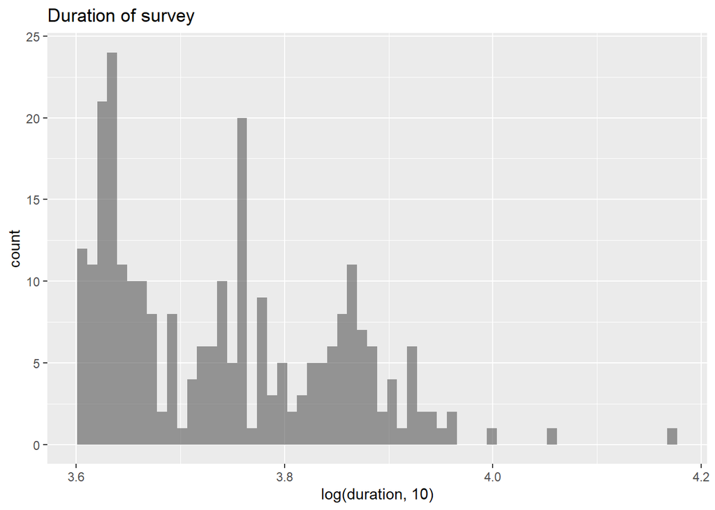

```r
## 3rd Quantile ~ maximum
multiple %>%
  mutate(duration = duration/60.) %>%
  filter(duration > 4000) %>%
  select(c(duration)) %>%
  ggplot(aes(log(duration,10),)) + geom_histogram(bins = 60, alpha=0.6, position = "identity") +
  ggtitle("Duration of survey")
```

4000분 이상인 데이터만 따로 잘라서 확인해 본 결과. 자르기로 결정! 4분 이하, 4000분 이상 데이터는 전부 잘랐다.

## 2. Confidence = NA 제거하기

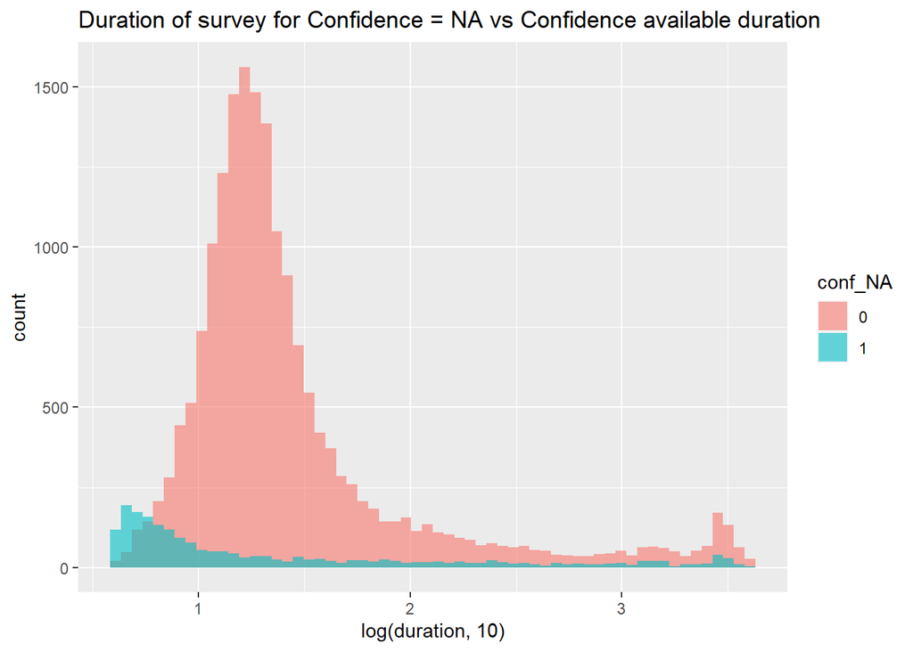

```r
## 4분 이하, 600분 이상 제거시 ??
multiple <- multiple %>%
  filter(duration/60. < 4000) %>%
  filter(duration/60. > 4)

## Confidence
na_conf <- which(multiple$confidence=="") ## 2093개

multiple %>%
  mutate(duration = duration/60.,
         conf_NA = as.factor(ifelse(multiple$confidence == "", 1, 0))) %>%
  select(c(duration, confidence, conf_NA)) %>%
  ggplot(aes(log(duration,10), fill = conf_NA)) + geom_histogram(bins = 60, alpha=0.6,
                                                           position = "identity") +
  ggtitle("Duration of survey for Confidence = NA vs Confidence available duration")
```

```r
## 1500 분 (25시간) 이상 : strange value.
## 초반 4~5분 : Strange value. 너무 짧은 시간 내에 응답을 마쳤다.

multiple_p <- multiple %>%
  filter(!multiple$confidence=="")
```

Confidence = NA 인 개체들이 너무 설문조사 시간이 짧다. 그래서 Confidence = 26번 문제까지 응답을 안했으며, 그 뒤의 값들도 많이 누락되어있어, 전체 제거하기로 결정.

## 3. Salary = NA 제거하기

```r
## Salary 이상치 :

summary(multiple_p$value)
```

```
##    Length     Class      Mode
##     18229 character character
```

```r
multiple_p$value[multiple_p$value==""] <- "No selection"
multiple_p[1:10, c("value")]
```

```
## # A tibble: 10 x 1
##    value
##    <chr>
##  1 No selection
##  2 10-20,000
##  3 0-10,000
##  4 No selection
##  5 0-10,000
##  6 I do not wish to disclose my approximate yearly compensation
##  7 10-20,000
##  8 0-10,000
##  9 No selection
## 10 20-30,000
```

```r
salary_buckets <- c("0-10,000", "10-20,000", "20-30,000", "30-40,000", "40-50,000",
                    "50-60,000", "60-70,000", "70-80,000", "80-90,000", "90-100,000",
                    "100-125,000", "125-150,000", "150-200,000", "200-250,000", "250-300,000",
                    "300-400,000", "400-500,000", "500,000+",
                    "I do not wish to disclose my approximate yearly compensation", "No selection")

multiple_p$value <- factor(multiple_p$value, levels = salary_buckets)
summary(multiple_p$value)
```

```
##                                                     0-10,000
##                                                         3515
##                                                    10-20,000
##                                                         1642
##                                                    20-30,000
##                                                         1199
##                                                    30-40,000
##                                                          969
##                                                    40-50,000
##                                                          862
##                                                    50-60,000
##                                                          824
##                                                    60-70,000
##                                                          654
##                                                    70-80,000
##                                                          622
##                                                    80-90,000
##                                                          463
##                                                   90-100,000
##                                                          506
##                                                  100-125,000
##                                                          753
##                                                  125-150,000
##                                                          494
##                                                  150-200,000
##                                                          413
##                                                  200-250,000
##                                                          152
##                                                  250-300,000
##                                                           67
##                                                  300-400,000
##                                                           43
##                                                  400-500,000
##                                                           18
##                                                     500,000+
##                                                           37
## I do not wish to disclose my approximate yearly compensation
##                                                         3561
##                                                 No selection
##                                                         1435
```

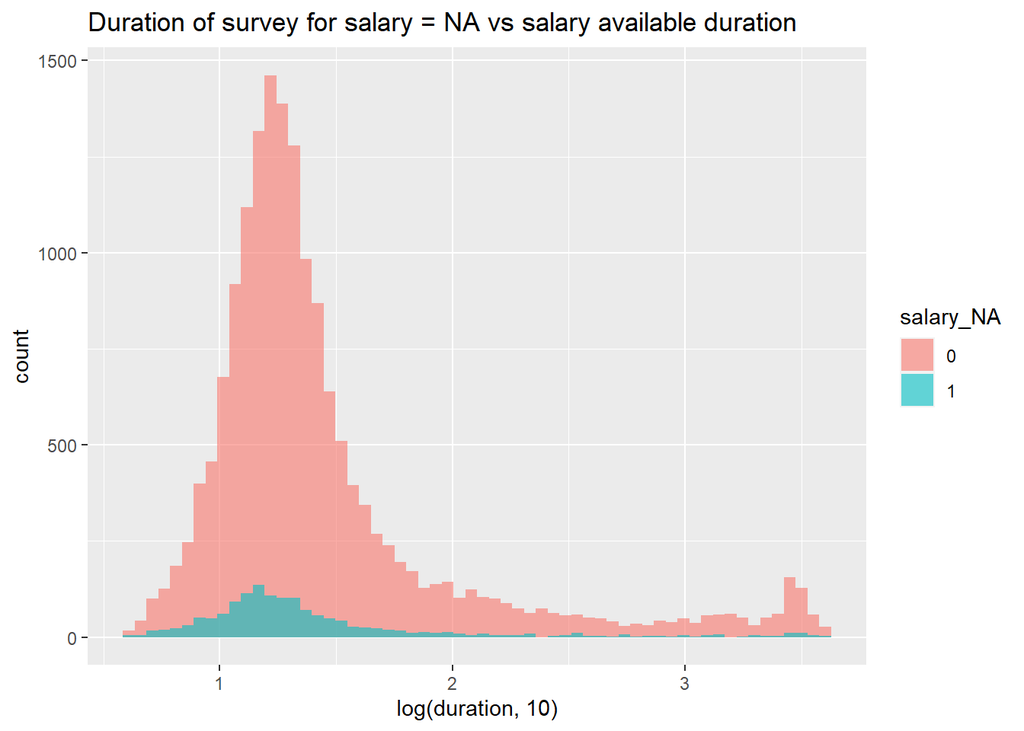

```r
na_salary <- which(multiple_p$value == "No selection") ## 1435개

multiple_p %>%
  mutate(duration = duration/60.,
         salary_NA = as.factor(ifelse(value == "No selection", 1, 0))) %>%
  select(c(duration, value, salary_NA)) %>%
  ggplot(aes(log(duration,10), fill = salary_NA)) + geom_histogram(bins = 60, alpha=0.6,
                                                         position = "identity") +
  ggtitle("Duration of survey for salary = NA vs salary available duration")
```

```r
summary(multiple_p[na_salary, 'duration'])
```

```
##     duration
##  Min.   :   245.0
##  1st Qu.:   744.5
##  Median :  1063.0
##  Mean   :  8128.2
##  3rd Qu.:  1836.5
##  Max.   :233518.0
```

```r
## 제거하지 않고 No selection -> do not want to disclose에 합치기.

multiple_p$value[multiple_p$value=="No selection"] <- "I do not wish to disclose my approximate yearly compensation"
multiple_p$value <- factor(multiple_p$value, levels = salary_buckets[-20])
summary(multiple_p$value)
```

```
##                                                     0-10,000
##                                                         3515
##                                                    10-20,000
##                                                         1642
##                                                    20-30,000
##                                                         1199
##                                                    30-40,000
##                                                          969
##                                                    40-50,000
##                                                          862
##                                                    50-60,000
##                                                          824
##                                                    60-70,000
##                                                          654
##                                                    70-80,000
##                                                          622
##                                                    80-90,000
##                                                          463
##                                                   90-100,000
##                                                          506
##                                                  100-125,000
##                                                          753
##                                                  125-150,000
##                                                          494
##                                                  150-200,000
##                                                          413
##                                                  200-250,000
##                                                          152
##                                                  250-300,000
##                                                           67
##                                                  300-400,000
##                                                           43
##                                                  400-500,000
##                                                           18
##                                                     500,000+
##                                                           37
## I do not wish to disclose my approximate yearly compensation
##                                                         4996
```

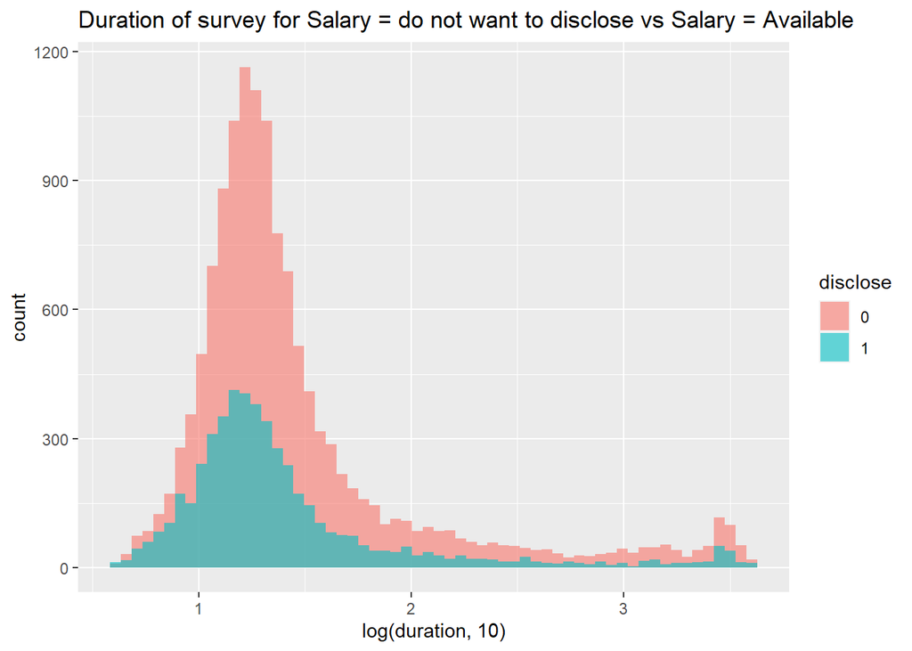

```r
## 아마 상위 20%로 구간 나눠서 fitting 해야 할지도.
multiple_p %>%
  mutate(duration = duration/60.,
         disclose = as.factor(ifelse(value == "I do not wish to disclose my approximate yearly compensation", 1, 0))) %>%
  select(c(duration, value, disclose)) %>%
  ggplot(aes(log(duration, 10), fill = disclose)) + geom_histogram(bins = 60, alpha=0.6,
                                                           position = "identity") +
  ggtitle("Duration of survey for Salary = do not want to disclose vs Salary = Available")
```

No Selection(NA) 값들이 너무 duration pattern과 비슷해서, 일단은 No selection과 I do not want to disclose를 합치고, 차후 fitting 과정에서 필요할 경우 제거하기로 한다.

## 4. Country : 5대륙으로 합치기.

```r
## Country = NA ?
sum(multiple_p$country=="") #NA 없어짐.
```

```
## [1] 0
```

```r
asia <- c("Bangladesh","China","Hong Kong (S.A.R.)","India","Indonesia","Iran, Islamic Republic of...","Israel",
          "Japan","Malaysia","Pakistan","Philippines","Republic of Korea","Singapore","South Korea","Thailand",
          "Turkey","Viet Nam")
europe <- c("Austria","Belarus","Belgium","Czech Republic","Denmark","Finland","France","Germany","Greece",
            "Hungary","Ireland","Italy","Netherlands","Norway","Poland","Portugal","Romania","Russia","Spain",
            "Sweden","Switzerland","Ukraine","United Kingdom of Great Britain and Northern Ireland")
southamerica <- c("Argentina","Brazil","Chile","Colombia","Peru")
northamerica <- c("Canada","Mexico","United States of America")
oceania <- c("Australia","New Zealand")
africa <- c("Egypt","Kenya","Morocco","Nigeria","South Africa","Tunisia")

asia.idx <- which(multiple_p$country %in% asia)
europe.idx <- which(multiple_p$country %in% europe)
southame.idx <- which(multiple_p$country %in% southamerica)
northame.idx <- which(multiple_p$country %in% northamerica)
oceania.idx <- which(multiple_p$country %in% oceania)
africa.idx <- which(multiple_p$country %in% africa)
region <- rep(NA,nrow(multiple_p))
region[asia.idx] <- "Asia"
region[europe.idx] <- "Europe"
region[southame.idx] <- "SouthAmerica"
region[northame.idx] <- "NorthAmerica"
region[oceania.idx] <- "Oceania"
region[africa.idx] <- "Africa"
multiple_p$country <- factor(region)

table(multiple_p$country)/sum(table(multiple_p$country))
```

```
##
##       Africa         Asia       Europe NorthAmerica      Oceania SouthAmerica
##   0.03090867   0.36515222   0.27579596   0.25714618   0.01864978   0.05234720
```

## 5. Student 합쳐주기 : Role = Student와 Industry = Student 합쳐주기.

```r
## Student 살리기 :
## 3. Student - 넣고 진행함. (salary no selection이 많음.)

table(multiple_p$Role); table(multiple_p$industry)
```

```
##
##        Business Analyst           Chief Officer              Consultant
##                     650                     307                     650
##            Data Analyst           Data Engineer         Data Journalist
##                    1544                     598                      12
##          Data Scientist   DBA/Database Engineer      Developer Advocate
##                    3503                     120                      87
##                 Manager       Marketing Analyst            Not employed
##                     511                      96                     718
##                   Other  Principal Investigator Product/Project Manager
##                    1116                      86                     363
##      Research Assistant      Research Scientist             Salesperson
##                     487                    1012                      84
##       Software Engineer            Statistician                 Student
##                    2487                     198                    3600
```

```
##
##                                                           Academics/Education
##                                    718                                   2177
##                     Accounting/Finance            Broadcasting/Communications
##                                   1235                                    329
##                   Computers/Technology                          Energy/Mining
##                                   4604                                    389
##              Government/Public Service       Hospitality/Entertainment/Sports
##                                    566                                    153
##                         I am a student              Insurance/Risk Assessment
##                                   3202                                    503
##              Manufacturing/Fabrication                          Marketing/CRM
##                                    476                                    413
##                 Medical/Pharmaceutical              Military/Security/Defense
##                                    670                                    153
##                     Non-profit/Service   Online Business/Internet-based Sales
##                                    157                                    300
## Online Service/Internet-based Services                                  Other
##                                    733                                    809
##                           Retail/Sales                Shipping/Transportation
##                                    387                                    255
```

```r
std.id <- unique(c(which(multiple_p$Role == "Student"), which(multiple_p$industry == "I am a student"))) ## 4189
sort(std.id, decreasing = TRUE)[1:10]
```

```
##  [1] 18227 18223 18222 18220 18219 18210 18200 18198 18197 18195
```

```r
table(multiple_p[std.id, "value"])
```

```
##
##                                                     0-10,000
##                                                         1730
##                                                    10-20,000
##                                                          245
##                                                    20-30,000
##                                                          147
##                                                    30-40,000
##                                                           83
##                                                    40-50,000
##                                                           30
##                                                    50-60,000
##                                                           19
##                                                    60-70,000
##                                                           14
##                                                    70-80,000
##                                                           15
##                                                    80-90,000
##                                                            7
##                                                   90-100,000
##                                                            9
##                                                  100-125,000
##                                                           13
##                                                  125-150,000
##                                                            8
##                                                  150-200,000
##                                                            3
##                                                  200-250,000
##                                                            2
##                                                  250-300,000
##                                                            0
##                                                  300-400,000
##                                                            3
##                                                  400-500,000
##                                                            0
##                                                     500,000+
##                                                            3
## I do not wish to disclose my approximate yearly compensation
##                                                         1858
```

```r
## total = 4189, 1858 choosed do not want to disclose yearly compensation.

multiple_p[std.id, "Role"] <- "Student"
multiple_p[std.id, "industry"] <- "Student"
```

## 6. Degree = I Prefer not to answer = 제거해주기.

```r
#Degree = NA 없어짐
sum(multiple_p$degree=="")
```

```
## [1] 0
```

```r
sum(multiple_p$degree=="I prefer not to answer") ## 178개
```

```
## [1] 196
```

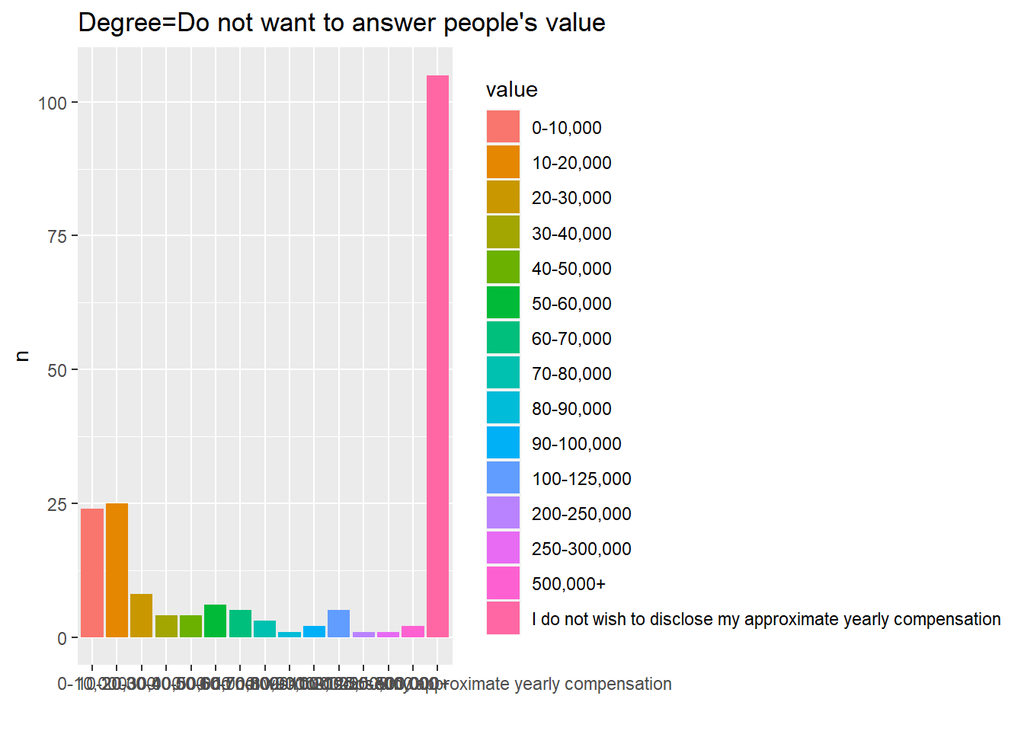

```r
## drop I prefer not to answer
multiple_p %>%
  select(degree, duration, value, Role, industry) %>%
  filter(degree == "I prefer not to answer") %>%
  group_by(value) %>% count() %>%
  ggplot(aes(x=value, y=n, fill=value)) + geom_bar(stat="identity") +
  labs(x="", title = "Degree=Do not want to answer people's value")
```

```r
## 압도적으로 value도 응답 없음이 많다. 제거!
```

Valeu 응답없음이 너무 많은 class이므로 삭제하기로 한다.

### 6-1) Degree = Not Answer 사람들의 이상한 패턴 :

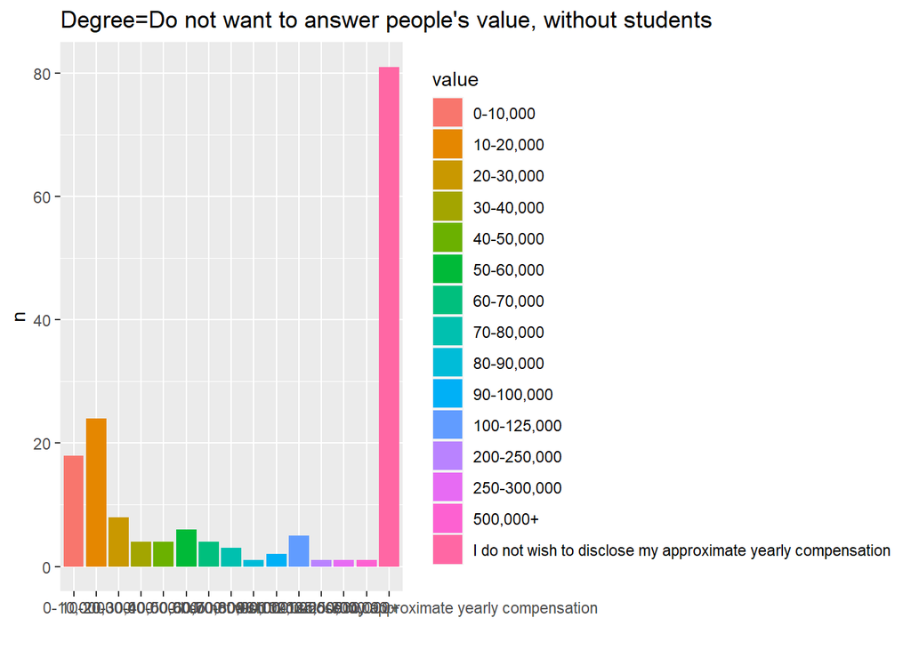

```r
multiple_p %>%
  select(degree, duration, value, Role, industry) %>%
  filter(degree == "I prefer not to answer") %>%
  filter(!Role == "Student") %>%
  group_by(value) %>% count() %>%
  ggplot(aes(x=value, y=n, fill=value)) + geom_bar(stat="identity") +
  labs(x="", title = "Degree=Do not want to answer people's value, without students")
```

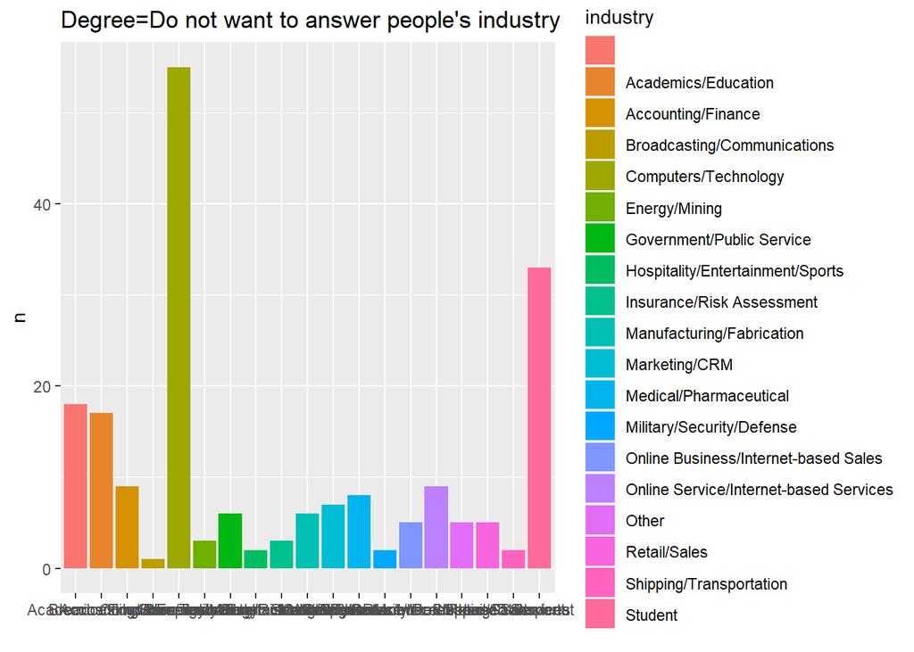

```r
## 초반부 조금 상승, No yearly compensation 변함 없음. 거의 Sofware Engineers. why??

multiple_p %>%
  select(degree, duration, value, Role, industry) %>%
  filter(degree == "I prefer not to answer") %>%
  group_by(industry) %>% count() %>%
  ggplot(aes(x=industry, y=n, fill=industry)) + geom_bar(stat="identity") +
  labs(x="", title = "Degree=Do not want to answer people's industry")
```

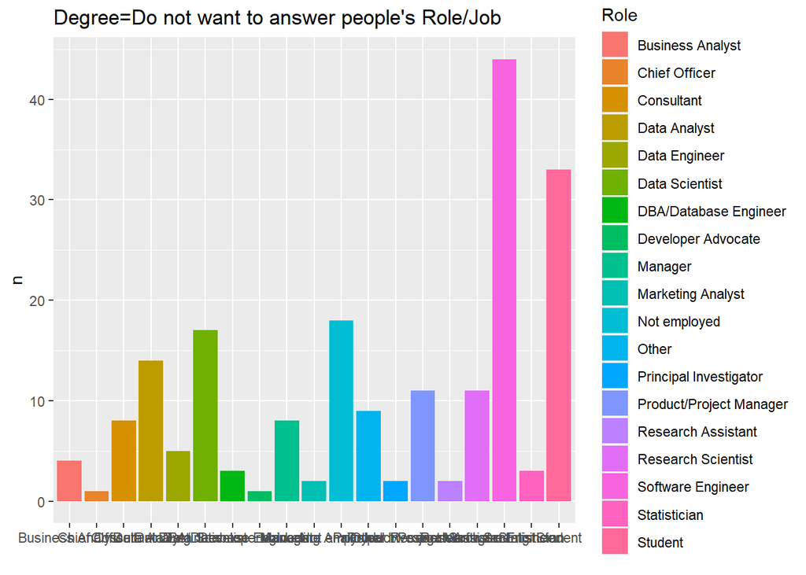

```r
## computer/tech가 대부분
## => 신기한 패턴! computer science 쪽의 178명은 자신의 학력을 기재하지 않음.

multiple_p %>%
  select(degree, duration, value, Role, industry) %>%
  filter(degree == "I prefer not to answer") %>%
  group_by(Role) %>% count() %>%
  ggplot(aes(x=Role, y=n, fill=Role)) + geom_bar(stat="identity") +
  labs(x="", title = "Degree=Do not want to answer people's Role/Job")
```

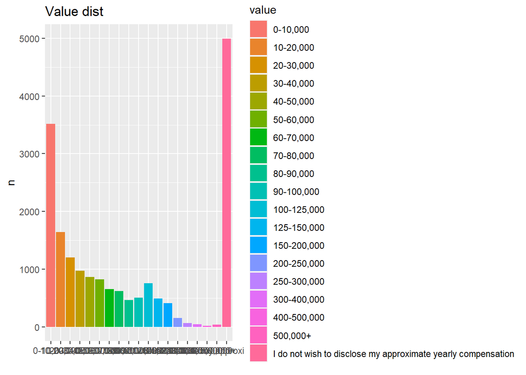

```r
## 거의 software engineer

multiple_p %>%
  select(value) %>%
  group_by(value) %>% count() %>%
  ggplot(aes(x=value, y=n, fill=value)) + geom_bar(stat="identity") +
  labs(x="", title = "Value dist")
```

```r
## Total distribution, do not want to disclose가 너무 많음.

multiple_p <- multiple_p %>%
  filter(!degree == "I prefer not to answer")
```

=> Degree = 밝히지 않고 싶어하는 사람들의 다수가 Software Engineer였다.

## 7. Role - Class 묶기.

```r
## 4. 변수 내 grouping 필요 - ML 총 5개로 재분류 필요. / DS, DA, Software Engineer, Others, Student
## ## DS, DA, Others, Software Engineer, Student
## Ds : DS, DA = BA + DA +
## Software Engineer : SE + DBA/Database Engineer
## overfitting경계를 위해서 총 5% 미만의 개체 응답 수는 제거.
## Remove not employed

table(multiple_p$Role)
```

```
##
##        Business Analyst           Chief Officer              Consultant
##                     615                     306                     639
##            Data Analyst           Data Engineer         Data Journalist
##                    1406                     562                      12
##          Data Scientist   DBA/Database Engineer      Developer Advocate
##                    3312                     114                      85
##                 Manager       Marketing Analyst            Not employed
##                     500                      93                     700
##                   Other  Principal Investigator Product/Project Manager
##                    1089                      84                     351
##      Research Assistant      Research Scientist             Salesperson
##                     435                     968                      82
##       Software Engineer            Statistician                 Student
##                    2345                     179                    4156
```

```r
# not empolyed 제거
multiple_p <- multiple_p %>%
  filter(!Role == "Not employed")

## DBA/Database Engineer+Data Engineer summation.
multiple_p[which(multiple_p$Role == "DBA/Database Engineer"), "Role"] <- 'Data Engineer/DBA'
multiple_p[which(multiple_p$Role == "Data Engineer"), "Role"] <- 'Data Engineer/DBA'

## Statistician + Research Scientist 합치기
multiple_p[which(multiple_p$Role == "Statistician"), "Role"] <- 'Statistician/Research Scientist'
multiple_p[which(multiple_p$Role == "Research Scientist"), "Role"] <- 'Statistician/Research Scientist'
## Sales person 제거
multiple_p[which(multiple_p$Role == "Salesperson"), "Role"] <- 'Others'

table(multiple_p[multiple_p$Role == "Research Assistant","value"])
```

```
##
##                                                     0-10,000
##                                                          130
##                                                    10-20,000
##                                                           63
##                                                    20-30,000
##                                                           50
##                                                    30-40,000
##                                                           41
##                                                    40-50,000
##                                                           19
##                                                    50-60,000
##                                                           20
##                                                    60-70,000
##                                                            9
##                                                    70-80,000
##                                                            6
##                                                    80-90,000
##                                                            5
##                                                   90-100,000
##                                                            2
##                                                  100-125,000
##                                                            2
##                                                  125-150,000
##                                                            1
##                                                  150-200,000
##                                                            0
##                                                  200-250,000
##                                                            0
##                                                  250-300,000
##                                                            0
##                                                  300-400,000
##                                                            0
##                                                  400-500,000
##                                                            0
##                                                     500,000+
##                                                            1
## I do not wish to disclose my approximate yearly compensation
##                                                           86
```

```r
table(multiple_p[multiple_p$Role == "Student","value"])
```

```
##
##                                                     0-10,000
##                                                         1724
##                                                    10-20,000
##                                                          244
##                                                    20-30,000
##                                                          147
##                                                    30-40,000
##                                                           83
##                                                    40-50,000
##                                                           30
##                                                    50-60,000
##                                                           19
##                                                    60-70,000
##                                                           13
##                                                    70-80,000
##                                                           15
##                                                    80-90,000
##                                                            7
##                                                   90-100,000
##                                                            9
##                                                  100-125,000
##                                                           13
##                                                  125-150,000
##                                                            8
##                                                  150-200,000
##                                                            3
##                                                  200-250,000
##                                                            2
##                                                  250-300,000
##                                                            0
##                                                  300-400,000
##                                                            3
##                                                  400-500,000
##                                                            0
##                                                     500,000+
##                                                            2
## I do not wish to disclose my approximate yearly compensation
##                                                         1834
```

```r
## Research_Assisent = 연구보조원. 연구실에서 일하는 직종!
## Ds = Ds
table(multiple_p[multiple_p$Role == "Research Assistant","degree"])
```

```
##
##                                                 Bachelor’s degree
##                                                                 76
##                                                    Doctoral degree
##                                                                156
##                                                   Master’s degree
##                                                                183
##                                                Professional degree
##                                                                  9
## Some college/university study without earning a bachelor’s degree
##                                                                 11
```

```r
table(multiple_p[multiple_p$Role == "Student","degree"])
```

```
##
##                                                 Bachelor’s degree
##                                                               1594
##                                                    Doctoral degree
##                                                                405
##                                                   Master’s degree
##                                                               1821
##                               No formal education past high school
##                                                                 14
##                                                Professional degree
##                                                                 47
## Some college/university study without earning a bachelor’s degree
##                                                                275
```

```r
## 사실상 phd. 연구원. modtly, Doctoral, and Master's degree
## Students로 넣어야 하나? Yes

multiple_p[which(multiple_p$Role == "Research Assistant"), "Role"] <- 'Student'
table(multiple_p$Role)
```

```
##
##                Business Analyst                   Chief Officer
##                             615                             306
##                      Consultant                    Data Analyst
##                             639                            1406
##               Data Engineer/DBA                 Data Journalist
##                             676                              12
##                  Data Scientist              Developer Advocate
##                            3312                              85
##                         Manager               Marketing Analyst
##                             500                              93
##                           Other                          Others
##                            1089                              82
##          Principal Investigator         Product/Project Manager
##                              84                             351
##               Software Engineer Statistician/Research Scientist
##                            2345                            1147
##                         Student
##                            4591
```

```r
## Principal Investigator ; 주로 교수님. 책임연구원.
table(multiple_p[multiple_p$Role == "Principal Investigator","degree"])
```

```
##
##                                                 Bachelor’s degree
##                                                                  1
##                                                    Doctoral degree
##                                                                 66
##                                                   Master’s degree
##                                                                 11
##                                                Professional degree
##                                                                  5
## Some college/university study without earning a bachelor’s degree
##                                                                  1
```

```r
## 대부분 Doctor's degree.
table(multiple_p[multiple_p$Role == "Principal Investigator","value"])
```

```
##
##                                                     0-10,000
##                                                            3
##                                                    10-20,000
##                                                            5
##                                                    20-30,000
##                                                            3
##                                                    30-40,000
##                                                            2
##                                                    40-50,000
##                                                            5
##                                                    50-60,000
##                                                            7
##                                                    60-70,000
##                                                            4
##                                                    70-80,000
##                                                            3
##                                                    80-90,000
##                                                            4
##                                                   90-100,000
##                                                            6
##                                                  100-125,000
##                                                            9
##                                                  125-150,000
##                                                            7
##                                                  150-200,000
##                                                           10
##                                                  200-250,000
##                                                            3
##                                                  250-300,000
##                                                            1
##                                                  300-400,000
##                                                            0
##                                                  400-500,000
##                                                            0
##                                                     500,000+
##                                                            1
## I do not wish to disclose my approximate yearly compensation
##                                                           11
```

```r
## 다만, 패턴이 학생과는 다름. 어디에 넣지....
table(multiple_p[multiple_p$Role == "Principal Investigator","industry"])
```

```
##
##                    Academics/Education                     Accounting/Finance
##                                     44                                      2
##                   Computers/Technology                          Energy/Mining
##                                      7                                      3
##              Government/Public Service       Hospitality/Entertainment/Sports
##                                      8                                      3
##              Insurance/Risk Assessment              Manufacturing/Fabrication
##                                      1                                      5
##                 Medical/Pharmaceutical              Military/Security/Defense
##                                      4                                      1
## Online Service/Internet-based Services                                  Other
##                                      1                                      2
##                Shipping/Transportation
##                                      3
```

```r
## drop data journalist,
c(table(multiple_p[multiple_p$Role == "Marketing Analyst", "value"]), table(multiple_p[multiple_p$Role == "Business Analyst", "value"]))
```

```
##                                                     0-10,000
##                                                           15
##                                                    10-20,000
##                                                            8
##                                                    20-30,000
##                                                           10
##                                                    30-40,000
##                                                            4
##                                                    40-50,000
##                                                            6
##                                                    50-60,000
##                                                            7
##                                                    60-70,000
##                                                            2
##                                                    70-80,000
##                                                            4
##                                                    80-90,000
##                                                            2
##                                                   90-100,000
##                                                            5
##                                                  100-125,000
##                                                            5
##                                                  125-150,000
##                                                            5
##                                                  150-200,000
##                                                            1
##                                                  200-250,000
##                                                            0
##                                                  250-300,000
##                                                            0
##                                                  300-400,000
##                                                            0
##                                                  400-500,000
##                                                            0
##                                                     500,000+
##                                                            0
## I do not wish to disclose my approximate yearly compensation
##                                                           19
##                                                     0-10,000
##                                                           71
```

[output cut: 21 more lines]

```
##                                                            5
##                                                  150-200,000
##                                                            6
##                                                  200-250,000
##                                                            1
##                                                  250-300,000
##                                                            0
##                                                  300-400,000
##                                                            0
##                                                  400-500,000
##                                                            0
##                                                     500,000+
##                                                            2
## I do not wish to disclose my approximate yearly compensation
##                                                          109
```

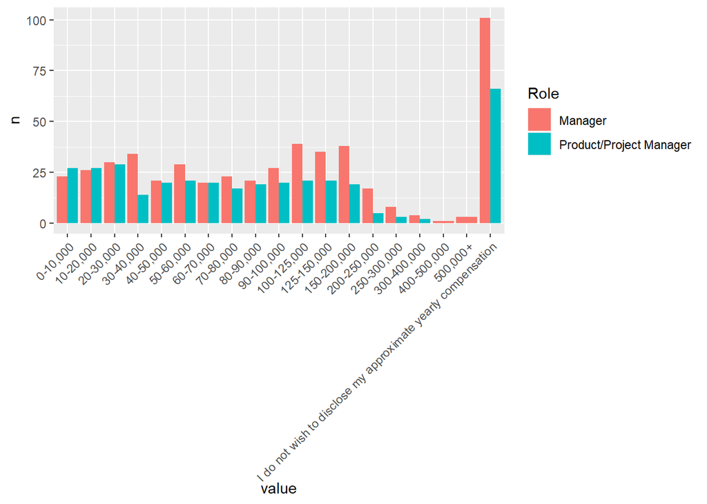

```r
multiple_p %>%
  filter(Role == "Product/Project Manager" | Role == "Manager") %>%
  select(Role, value) %>%
  group_by(Role, value) %>% count() %>%
  ggplot(aes(x = value, y = n, fill = Role)) + geom_bar(stat="identity", position=position_dodge()) +
  theme(axis.text.x = element_text(angle = 45, hjust = 1))
```

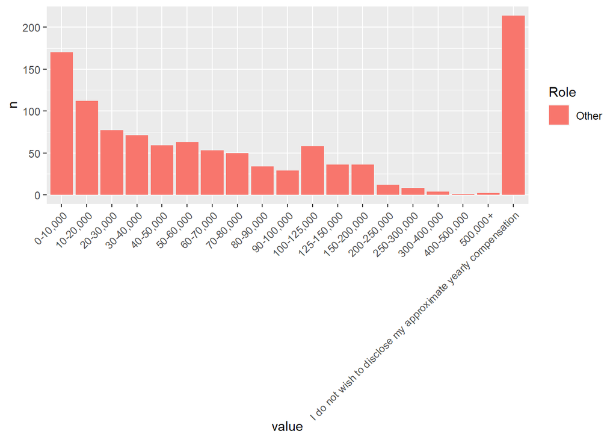

```r
multiple_p %>%
  filter(Role == "Other") %>%
  select(Role, value) %>%
  group_by(Role, value) %>% count() %>%
  ggplot(aes(x = value, y = n, fill = Role)) + geom_bar(stat="identity", position=position_dodge()) +
  theme(axis.text.x = element_text(angle = 45, hjust = 1))
```

```r
table(multiple_p[which(multiple_p$value=="I do not wish to disclose my approximate yearly compensation"), "Role"])/
  sum(multiple_p$value=="I do not wish to disclose my approximate yearly compensation")
```

```
##
##                Business Analyst                   Chief Officer
##                     0.026008113                     0.020281556
##                      Consultant                    Data Analyst
##                     0.034597948                     0.058458602
##               Data Engineer/DBA                 Data Journalist
##                     0.026246719                     0.001431639
##                  Data Scientist              Developer Advocate
##                     0.115724171                     0.004533524
##                         Manager               Marketing Analyst
##                     0.024099260                     0.004533524
##                           Other                          Others
##                     0.051061799                     0.003579098
##          Principal Investigator         Product/Project Manager
##                     0.002624672                     0.015748031
##               Software Engineer Statistician/Research Scientist
##                     0.104509664                     0.048437127
##                         Student
##                     0.458124553
```

```r
multiple_p <- multiple_p %>%
  filter(!Role == "Other")

## Student가 do not want to disclose my early compensation의 대부분을 차지한다. 거의 45%.
#developer advocate = head hunter? 개발자 영입자.
tb <- table(multiple_p$Role)/sum(table(multiple_p$Role))
## 5% 미만 개체 전부 out :
tb
```

```
##
##                Business Analyst                   Chief Officer
##                    0.0378601330                    0.0188377247
##                      Consultant                    Data Analyst
##                    0.0393376016                    0.0865550357
##               Data Engineer/DBA                 Data Journalist
##                    0.0416153657                    0.0007387343
##                  Data Scientist              Developer Advocate
##                    0.2038906673                    0.0052327013
##                         Manager               Marketing Analyst
##                    0.0307805959                    0.0057251908
##                          Others          Principal Investigator
##                    0.0050480177                    0.0051711401
##         Product/Project Manager               Software Engineer
##                    0.0216079783                    0.1443609948
## Statistician/Research Scientist                         Student
##                    0.0706106870                    0.2826274317
```

```r
tb[tb > 0.05]
```

```
##
##                    Data Analyst                  Data Scientist
##                      0.08655504                      0.20389067
##               Software Engineer Statistician/Research Scientist
##                      0.14436099                      0.07061069
##                         Student
##                      0.28262743
```

```r
role <- c(names(tb[tb > 0.05]), "Business Analyst", "Data Engineer/DBA")

multi_test <- multiple_p %>%
  filter(Role %in% role)
table(multi_test$Role)
```

```
##
##                Business Analyst                    Data Analyst
##                             615                            1406
##               Data Engineer/DBA                  Data Scientist
##                             676                            3312
##               Software Engineer Statistician/Research Scientist
##                            2345                            1147
##                         Student
##                            4591
```

```r
#https://www.kaggle.com/andresionek/is-there-any-job-out-there-kaggle-vs-glassdoor
## DS, SE, Statistician, Data Analyst, Engineer/DBA, Business Analyst
## Other은 빼야겠다.
## Student는 일단 넣고 시작.
```

- Not employed, data journalist : 제거, (journalist의 경우 너무 작은 proportion을 차지 =)
- DBA/DataBase Engineer, Data Engineer => 합쳐서 Data Engineer/DBA로 교체
- Statistician, Research Scientist => Statistician/Research Scientist로 합침.
- salesperson : Others로 묶음
- Research_Assistant : 사실상 phD, 연구보조로 Students와 패턴이 유사하므로 묶어줌
- Principal Investigator : 주로 교수님. 책임연구원. 다만 패턴이 학생과는 다르므로 남겨둠.
- Manager와 Product Manager묶기에도 패턴이 많이 다르다.

=> 이상패턴 : Student가 do not want to disclose my early compensation의 대부분을 차지한다. 거의 45%를 차지 . => 이 이유로, 이후 분석에서 I do not want to disclose my yearly compensation observation을 제거하고 vs 제거하지 않고 fitting진행함.

- 이렇게 분류한 뒤에, Role들 중 개체 수가 전체의 5%에 미달하는 것들은 제거해 주었다. (너무 작은 개체수를 차지, Overfitting 경계), 다만 연봉 분류에 중요할 것이라 예상되는 “Business Analyst”, “Data Engineer/DBA”의 경우 추가로 더해주었다.

(근거 : #https://www.kaggle.com/andresionek/is-there-any-job-out-there-kaggle-vs-glassdoor)

## 8. drop other gender

```r
multi_test <- multi_test %>%
  filter(!Role %in% c("Prefer not to say", "Prefer to self-describe"))
table(multi_test$Age)
```

```
##
## 18-21 22-24 25-29 30-34 35-39 40-44 45-49 50-54 55-59 60-69 70-79   80+
##  1786  3202  3945  2354  1242   665   373   249   143   106    18     9
```

```r
multi_test <- multi_test %>%
  mutate_if(is_character, as.factor)
```

```r
## 실험
multi_test2 <- multi_test %>%
  mutate(Language = str_c(Q16_Part_1, Q16_Part_2, Q16_Part_3, Q16_Part_4, Q16_Part_5, Q16_Part_6, Q16_Part_7,
                           Q16_Part_8, Q16_Part_9, Q16_Part_10, Q16_Part_11, Q16_Part_12, Q16_Part_13, Q16_Part_14,
                           Q16_Part_15, Q16_Part_16, Q16_Part_17, Q16_Part_18, sep=""))
sum(is.na(multi_test2$Language))
```

```
## [1] 0
```

```r
q16.null.id <- multi_test2 %>%
  filter(Language == "") ## Nothing

multi_test2 <- multi_test %>%
  mutate(Data = str_c(Q31_Part_1, Q31_Part_2, Q31_Part_3, Q31_Part_4, Q31_Part_5, Q31_Part_6, Q31_Part_7,
                          Q31_Part_8, Q31_Part_9, Q31_Part_10, Q31_Part_11, Q31_Part_12, sep=""))
sum(is.na(multi_test2$Data))
```

```
## [1] 0
```

```r
q31.null.id <- multi_test2 %>%
  filter(Data == "") ## Nothing

table(multiple_p$degree)
```

```
##
##                                                 Bachelor’s degree
##                                                               4792
##                                                    Doctoral degree
##                                                               2577
##                                                   Master’s degree
##                                                               7743
##                               No formal education past high school
##                                                                102
##                                                Professional degree
##                                                                431
## Some college/university study without earning a bachelor’s degree
##                                                                599
```

```r
write_csv(multi_test, "D:/project/ML_DS/multiple.csv", na="NA", append = FALSE, col_names = TRUE)
```

시간이 너무 오래 걸려서 여기서 데이터 만들어다 python으로 fitting 진행함.